# razimuth: user guide

## Installation

Prior to installation, ensure a compiler (`Rtools` for Windows, `gfortran` for macOS) has been associated with R. To install the package, execute the following via the command line

```
R CMD INSTALL razimuth_0.1.0.tar.gz
```

If a dependency is not available, install package and then rerun the above command.

## Example dataset

To begin, use the package’s `sim_atd()` function to simulate an example azimuthal telemetry dataset.

```r
set.seed(3141)
grouse <- sim_atd(n_loc = 100, sq_km = 4, n_azimuth = 3, dist_vec = c(200,300),
                  kappa_sim = 50, prior_r = 1000, plot = FALSE)$sim_df
head(x = grouse, n = 3)
```

```
##     indiv obs_id    utm_x   utm_y azimuth                date prior_r
## 1 sim_hen      1 494167.5 4489043     268 2017-11-29 17:00:00    1000
## 2 sim_hen      1 494008.0 4489283     203 2017-11-29 17:00:00    1000
## 3 sim_hen      1 493803.3 4488854      37 2017-11-29 17:00:00    1000
```

`grouse` represents a typical azimuthal telemetry dataset with the likely exception of the `prior_r` column. In this framework, the quantity `prior_r` is defined as the maximum distance (in meters) between the observer and the transmitter prior to taking the azimuth. This quantity will likely be derived from a combination of situational factors such as user experience level and/or landscape topography. In cases where this information was not obtained during data collection, the user must still specify an upper bound for each azimuth.

The function `convert_atm()` is used to convert the data frame into a list object necessary for subsequent plotting and model fitting.

```r
grouse_atm <- convert_atm(df = grouse)
```

The function `visualize_atm()` can be used to explore the geometry of each individual relocation attempt.

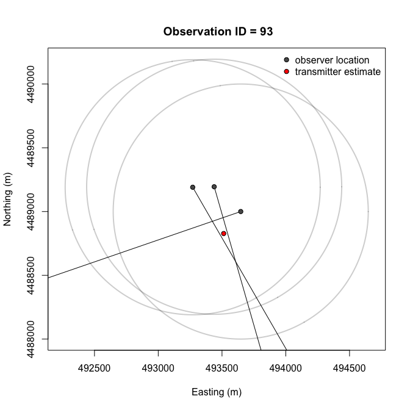

```r
visualize_atm(atm_df = grouse_atm, obs_id = 93, add_prior = T)
```

The `atm_mcmc()` function is used to fit the Azimuthal Telemetry Model (ATM) using Markov Chain Monte Carlo.

```r
atm_fit <- atm_mcmc(atm_df = grouse_atm, n_mcmc = 11000, n_burn = 1000)
```

```
## [[--START--]]
##
## [[--generating grids--]]
## [1][2][3][4][5][6][7][8][9][10][11][12][13][14][15][16][17][18][19][20][21][22][23][24][25][26][27][28][29][30][31][32][33][34][35][36][37][38][39][40][41][42][43][44][45][46][47][48][49][50][51][52][53][54][55][56][57][58][59][60][61][62][63][64][65][66][67][68][69][70][71][72][73][74][75][76][7…
##
## [[--mcmc--]]
## [100][200][300][400][500][600][700][800][900][1000][1100][1200][1300][1400][1500][1600][1700][1800][1900][2000][2100][2200][2300][2400][2500][2600][2700][2800][2900][3000][3100][3200][3300][3400][3500][3600][3700][3800][3900][4000][4100][4200][4300][4400][4500][4600][4700][4800][4900][5000][5100]…
##
## [[--post-processing mcmc output--]]
##
## [[--END--]]
```

The resulting object `atm_fit` contains the following model output:

- `mu_ls` - list of lists corresponding to each relocation attempt. Each list contains information about the relocation: identifier (`pid`), date (`date`), posterior mode (`pmode`), and a matrix containing the posterior draws (`pdraws`).
- `kappa_ls` - list containing information concerning the concentration parameter kappa: acceptance rate (`acceptance`), posterior draws (`pdraws`), and tuning parameter values from the adaptive tuning performed during burn in (`tuning`).
- `pmode_mat` - matrix containing the posterior modes for each relocation.

For plotting model output associated with a particular relocation, the helper function `which_pid()` is used to identify the list within `mu_ls` or row number of `pmode_mat` associated with the specified relocation identifier (`obs_id`). To plot posterior credible isopleths, use the `p_isopleth()` function.

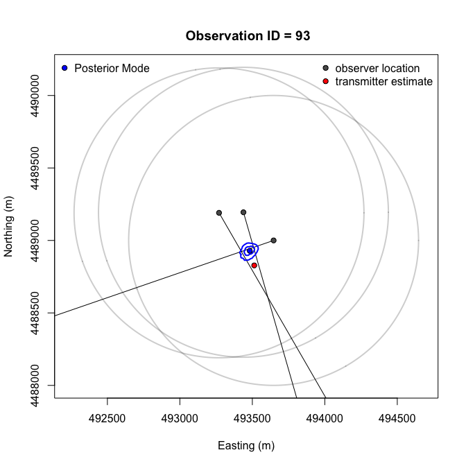

```r
id_tmp <- which_pid(atm_df = grouse_atm, obs_id = 93)
visualize_atm(atm_df = grouse_atm, obs_id = id_tmp, add_prior = TRUE)
p_isopleth(df = atm_fit$mu_ls[[id_tmp]]$pdraws, prob_lvls = c(0.5,0.9), range_extend = 0,
           kde_n = 50, col_vec = c(4,4))
points(matrix(atm_fit$pmode[id_tmp, 2:3], ncol = 2), pch = 21, bg = 4)
legend("topleft", c("Posterior Mode"), pch = 21, pt.bg = 4, bty = "n")
```

Plotting transmitter location posterior draws using a color scale such as `viridis` (from the `viridis` R package) helps to visualize 2-dimensional mixing.

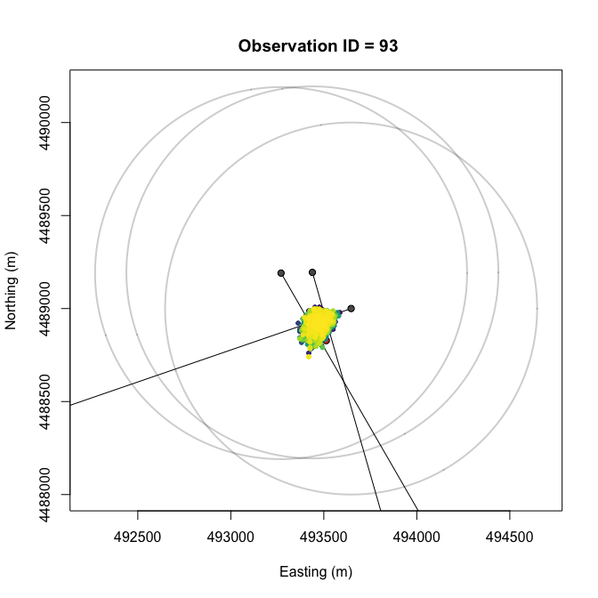

```r
visualize_atm(atm_df = grouse_atm, obs_id = id_tmp, add_prior = T, add_legend = F)
points(atm_fit$mu_ls[[id_tmp]]$pdraws, pch = 20,
       col = viridis::viridis(n = nrow(atm_fit$mu_ls[[id_tmp]]$pdraws)))
```

To assess convergence of the concentration parameter kappa, the `plot_kappa()` provides the following diagnostics per the `item` argument: traceplot (`traceplot`), posterior kernel density estimate (`density`), tuning parameter update trace (`tuning`), and running mean plot (`run_mean`).

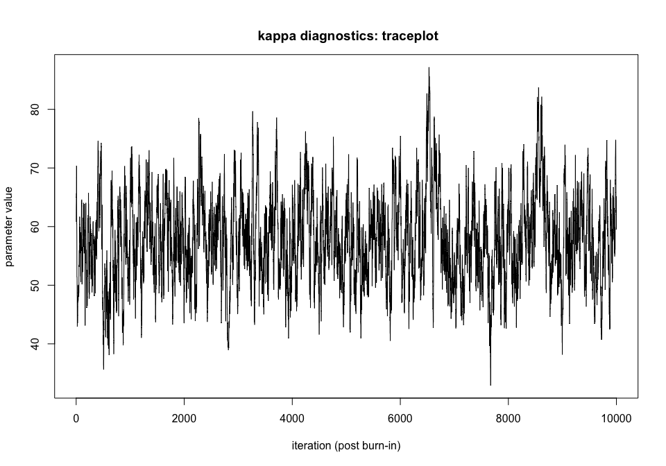

```r
plot_kappa(atm_obj = atm_fit$kappa_ls, item = "traceplot")
```

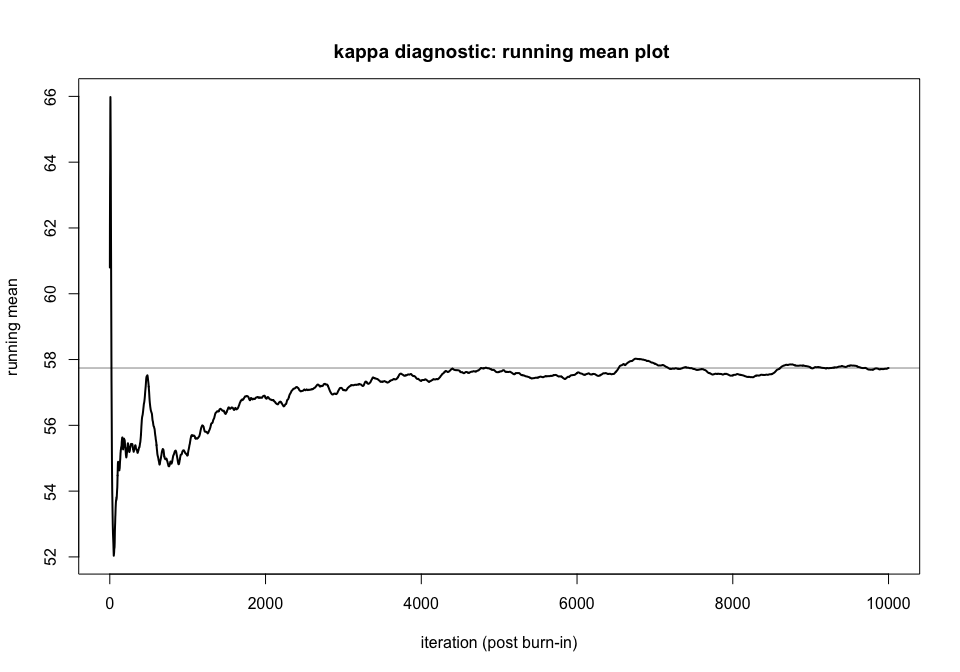

```r
plot_kappa(atm_obj = atm_fit$kappa_ls, item = "run_mean")
```